# Proyecto entrega 2

- Antonio Lomelí Ureña - Carolina Martínez - Enrique Tonatiuh Pérez Cortés - Eddie Aguilar

2024-02-22

## Introducción

Tanto el precio como el rendimiento de las acciones de una empresa son factores fundamentales para los inversionistas. Sin embargo, estos elementos están influenciados por diversas situaciones externas que afectan la economía a diferentes niveles. En este proyecto, se visualizará y analizará el precio de la acción de FEMSA a lo largo del tiempo, centrándonos en el período desde el año 2000. FEMSA inició su participación en la Bolsa Mexicana de Valores en 1978, pero por limitaciones en la importación de datos, solo se considerará el período a partir del 2000. Se analizará el comportamiento histórico del precio de la acción para identificar tendencias y comportamientos atípicos. Se identificarán y señalarán los comportamientos atípicos en el precio de la acción de FEMSA durante el período analizado. Se realizará una breve investigación para entender las posibles causas de estas variaciones anormales.

Dado que FEMSA es una empresa mexicana, se comparará el rendimiento anual de su acción con indicadores económicos relevantes a nivel nacional, en este caso el crecimeinto económico del país. Se proporcionará un análisis detallado de los resultados obtenidos.Es crucial dar seguimiento constante al precio de una acción para los inversionistas. En esta sección, se expondrán algunos de los elementos y situaciones actuales que pueden estar impactando el precio de la acción de FEMSA. Se realizará un análisis de cómo estos factores podrían influir en el rendimiento futuro de la acción. El análisis del precio de la acción de FEMSA proporcionará una visión integral de su comportamiento a lo largo del tiempo y cómo está influenciado por factores internos y externos. Esto ayudará a los inversionistas a tomar decisiones informadas y a comprender mejor el rendimiento de la empresa en el contexto económico actual.

## Precio y rentabilidad a través del tiempo

### Gráfica

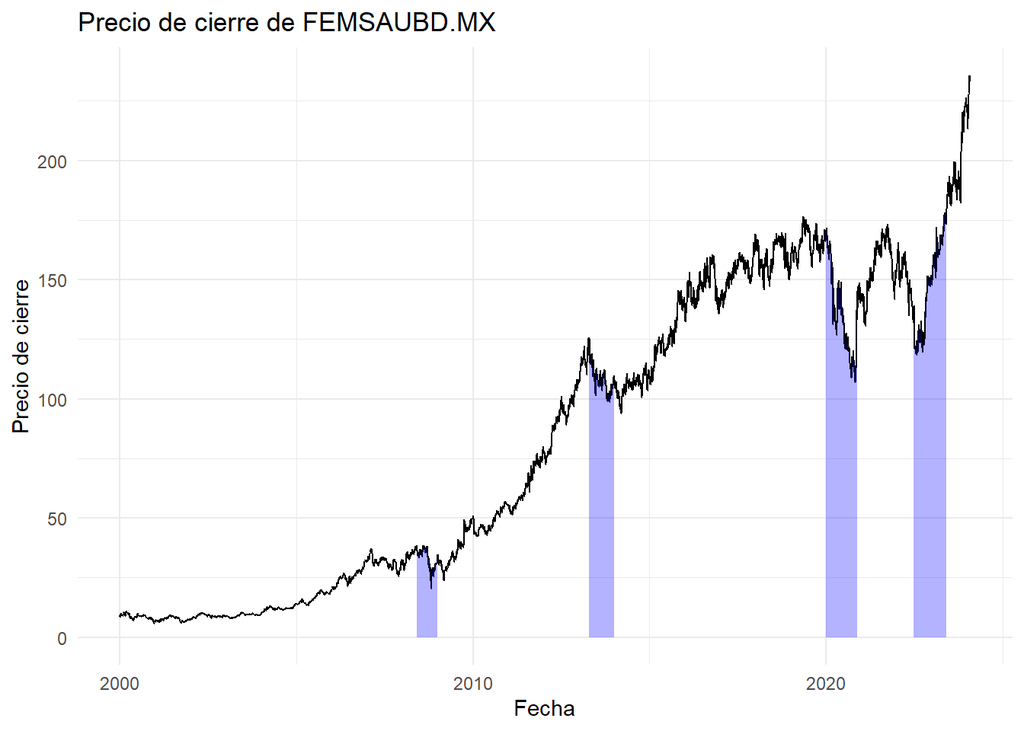

### Identificación y análisis de cambios en el comportamiento del precio

**2008 A 2009**

La crisis económica mundial comenzó en 2008, se originó en Estados Unidos. Entre los principales factores causantes de la crisis se encuentran los altos precios de las materias primas, la sobrevalorización del producto, una crisis alimentaria mundial, una elevada inflación en todo el mundo y la amenaza de una recesión en todo el mundo, a esto se le sumó una crisis crediticia, hipotecaria y de confianza en los mercados.

Debido a la alta dependencia de la economía mexicana en su comercio exterior con los EEUU y a la caída en las remesas provenientes de los migrantes (segunda fuente de divisas después del petróleo), debido a todo lo que estaba ocurriendo en EEUU, México resintió los efectos de la crisis rápidamente, causando que el desempleo abierto en el país subiera a 4.06%. Diversos factores como la dependencia del precio del petróleo y su caída en la producción obligaron al país a elevar el IVA, el ISR e instaurar impuestos nuevos a las telecomunicaciones.

El año 2009 fue especialmente difícil para la economía mexicana. Al iniciar el año, las expectativas oficiales pronosticaban un crecimiento a lo largo de 2009. Sin embargo, al pasar los meses las expectativas fueron tomando caminos más pesimistas y en ocasiones contradictorios, la epidemia de la gripe AH1N1 no ayudó a esto ya que el sector turístico se vio severamente afectado.

Por otro lado, desde 2008 el peso mexicano entró en una serie de devaluaciones frente al dólar estadounidense que lo llevaron a perder alrededor del 25% de su valor hacia 2009. Entre las medidas que se tomaron para contener la devaluación del peso se aplicó la subasta de una parte de la reserva de divisas internacionales, lo que llevó al país a gastar más de 20 mil millones de dólares estadounidenses sin lograr los resultados esperados (Blanco & Cantero, s. f.).

Si bien la crisis del 2008-2009 afectó a múltiples empresas mexicanas, algunas empresas líderes de sectores clave del mercado nacional, como telecomunicaciones, vivienda, alimentos y bebidas y ventas minoristas pudieron enfrentarla de muy buena manera, en el caso de FEMSA se reflejó en incrementos y beneficios netos de hasta 60%, según información del cierre del 2009 reportada por la BMV. Esto debido a que FEMSA participa en un mercado de poca sensibilidad a los cambios en el ingreso de los consumidores, lo que provoca incrementos en sus ventas y utilidades operativas. La empresa obtuvo buenos resultados debido a que el consumo básico cayó poco (Amador, 2010).

Una de las medidas que apoyó a reducir la ligera caída de FEMSA en 2009 fue que la empresa reprogramó sus inversiones, en 2008 invirtió en la expansión de su negocio en cerveza, refrescos y tiendas de conveniencia en México y Latinoamérica, pero las inversiones que tenía planificadas para cerrar el 2008, las pasó para el año siguiente, lo que permitió que el impacto financiero se redujera (Martínez, 2008).

**SUBIDA DE 2010 A 2014**

Durante el año 2010 a pesar de un entorno complicado con baja demanda en el consumo, FEMSA registró un crecimiento del 5.9% en los ingresos totales consolidados comparables y un aumento del 6.6% en la utilidad de operación en comparación con 2009. Este crecimiento fue impulsado principalmente por FEMSA Comercio y la operación en Mercosur de Coca-Cola FEMSA.

Coca-Cola FEMSA experimentó un aumento del 7.9% en la utilidad de operación, impulsado por un fuerte crecimiento en Mercosur y Latincentro y FEMSA Comercio continuó su rápido crecimiento al abrir 1,092 tiendas netas en 2010, con un aumento del 16.7% en la utilidad de operación.

En cuanto a los resultados financieros, los ingresos totales crecieron un 3.8% en el cuarto trimestre de 2010 en comparación con el mismo período en 2009, principalmente impulsados por FEMSA Comercio. La utilidad de operación creció en el cuarto trimestre de 2010 en comparación con el mismo período en 2009 y la utilidad neta por operaciones continuas aumentó significativamente, reflejando el crecimiento de las operaciones continuas de FEMSA.

La inversión en activo fijo aumentó en el cuarto trimestre como en el año 2010, con un saldo de efectivo en aumento y una posición de caja neta sólida (FEMSA, 2011).

Esta tendencia continuó con los años, en el tercer trimestre de 2014 FEMSA obtuvo un incremento de 13.2% en los ingresos comparado con el mismo periodo de 2013, así como un alza de las utilidades de operación de 15.8% en el mismo lapso, la empresa resaltó el crecimiento tanto de FEMSA Comercio y Coca-Cola FEMSA.

Así, en comparación con 2013, Coca-Cola FEMSA logró aumentar sus ingresos totales 11.4%, mientras que la utilidad de operación creció en 15.1% y FEMSA Comercio logró un incremento en ingresos de 12.7% y la utilidad de operación marcó una subida de 17.6%, esto último impulsado por 1,185 aperturas netas de tiendas y un crecimiento de 3.1% en ventas de las mismas tiendas.

Sin embargo, en los primeros nueve meses del 2014, la utilidad neta consolidada disminuyó 1.2% comparada con el mismo periodo del 2013, reflejando mayores gastos de financiamiento relacionados con la emisión de bonos por Coca-Cola FEMSA y FEMSA, que fueron parcialmente compensados por el crecimiento en los ingresos de operación (T21, 2014).

**CAÍDA EN 2020**

La economía mundial se hundió en 2020 debido a la pandemia por COVID-19 que se originó a finales de 2019. El desempleo y la pobreza se elevaron y muchas empresas pequeñas tuvieron que cerrar. A mediados de este año, el Banco Mundial estimó que la economía mundial se reduciría un 5.2% En su informe “Perspectivas económicas mundiales” planteó que esta sería la peor recesión desde la Segunda Guerra Mundial (Banco Mundial, 2022).

Como los demás, México fue un país que se vio afectado por este suceso y tuvo consecuencias notorias en su economía. En tan solo un año, la economía mexicana bajó un 8.5%, siendo la mayor caída desde la Gran Depresión (Cullell et.al., 2021). Durante el 2020, los ingresos de FEMSA cayeron 10.7% en el segundo trimestre del año debido a la pandemia por COVID-19. Esto se tradujo como una pérdida neta de 10,775 millones de pesos. Esta pérdida también estuvo influenciada por el cierre de las operaciones de Specialty’s Café and Bakery, así como un impacto negativo de la participación de FEMSA en los resultados de Heineken. Tras reportar estas pérdidas a la BMV el precio de su acción cayó un 1.53%.

Las tiendas OXXO disminuyeron sus ventas debido a las restricciones de movilidad impuestas, haciendo que los consumidores disminuyeran sus compras. A esto se sumó la falta de cerveza y otras bebidas alcohólicas. En cuanto al sector de salud, este tuvo un mejor desempeño, lógico por el contexto que se vivió en ese año. La demanda de los productos se mantuvo elevada, aunque las ventas también se vieron afectadas por las restricciones y el aislamiento. La baja considerable en el uso de los vehículos fue la causa de que la división referente a las gasolineras fuese la más afectada (Santiago, 2020).

**2021**

En 2021, México experimentó una recuperación gradual en su economía. Si bien todavía no llegaba a ser estable después de la recaída que sufrió por la pandemia en 2020, mostraba una tendencia al alza prometedora después del pico principal de la pandemia.

Según el Gobierno de México, el PIB del país reportó un crecimiento del 1.0% real en el cuarto trimestre de 2021 con respecto al cuarto trimestre de 2020. Esto debido a un 4.8% de crecimiento real anual sobre las actividades principales, mientras que en las actividades secundarias fue de 1.6% de crecimiento y las actividades terciarias solo un 0.1% de crecimiento (o incluso nula). Esto también refleja los efectos que tuvieron ciertas oleadas y replicas dentro de la pandemia debido a ciertas variantes de COVID-19, ya que, si bien sí afectaron a la economía, fueron solamente las actividades terciarias las que se vieron más detenidas, incluso llegando a tener un retroceso real trimestral de 0.7% de las actividades terciarias en el cuarto trimestre a comparación del trimestre inmediato anterior.

En cuanto a la bolsa y mercado de valores, el Grupo Bolsa Mexicana de Valores reportó una utilidad de $1,050 millones de pesos en el cuarto trimestre de 2021 a comparación del mismo trimestre del año anterior, lo cual se traduce en un 10% de utilidades. Al mismo tiempo, con el objetivo de disminuir las posibilidades de contagio, la pandemia dejó dinámicas que además disminuyeron gastos de la operación, lo cual también aportó a un mejor margen operativo. (Grupo BMV, 2021)

De la misma forma, FEMSA no fue excepción a esta tendencia que la bolsa y la economía en general mexicana sufrió durante el año. Los ingresos totales consolidados de FEMSA incrementaron 12.8% en 2021 a comparación del año anterior. Justamente viendo el efecto que la pandemia tuvo en los gastos de las empresas, FEMSA tuvo un gasto de operación consolidado mayor en 9.2%; sin embargo, esto debido al incremento en sus ingresos y ventas totales, ya que, si vemos el gasto a nivel porcentual, nos damos cuenta de que los gatos se redujeron de un 30.1% a 29.1% en 2021. (FEMSA, 2021)

A pesar de que la pandemia tuvo un fuerte impacto en las finanzas de la empresa, también hubo otros acontecimientos relevantes que empujaron las ventas e ingresos de esta, algunos de los más relevantes fueron:

- Coca-Cola FEMSA incluida en el Anuario de Sostenibilidad Global 2021.
- Coca-Cola FEMSA confirma adquisición de marca de cerveza Therezópolis.
- FEMSA expande su distribución en la costa este de Estados Unidos.
- Coca-Cola FEMSA anuncia acuerdo de distribución con Estrella Galicia en Brasil.
- Sucesión en su Dirección General.

**BAJADA EN 2022**

En julio de 2022, las acciones de FEMSA tuvieron su mayor caída desde el comienzo de la pandemia después de que acordó la compra de la compañía suiza Valora por 1,200 millones de dólares. Las acciones cayeron un 6.4%. Esta adquisición representó una prima del 52% sobre el precio de cierre del lunes, la cual fue tomada como excesiva por muchos de los inversionistas (Navarro, 2022).

**SUBIDA EN 2023**

Durante el año 2023, las acciones de FEMSA crecieron del 46%. Este aumento fue consecuencia del reacomodo de sus planes para enfocarse en sus negocios estratégicos. A principios de 2022, la compañía anunció una estrategia en la que se pretendía deshacerse de los negocios no estratégicos para enfocarse en Oxxo, farmacias, gasolineras y la división Coca-Cola. Roberto Solano, analista de Monex Casa de Bolsa, aseguró que FEMSA consiguió una cantidad de capital importante que será invertida en los próximos años en sus negocios de Coca-Cola FEMSA, Oxxo, farmacias, y gasolineras, así como en su área digital con Spin y Oxxo Premia. Además de esta estrategia, la empresa tuvo sólidos resultados financieros en 2023,impulsados por el crecimiento de las ventas y la utilidad de la división de Oxxo, lo que a su vez apoyó al crecimiento del precio de la acción dentro de la Bolsa Mexicana de Valores. De enero a septiembre de 2023, las ventas tuvieron un incremento del 19.4% con respecto al año anterior (El Economista, 2023).

## Precio contra Producto Interno Bruto

### Gráfica

[figure not shown]

### Análisis

Tiene sentido que el PIB se mueva poco, ya que es un agregado de todo el comportamiento económico, mientras que el precio de una acción es influenciado por factores específicos para esa empresa, como los resultados de la empresa, el panorama de la industria, las expectativas del mercado y las tasas de interés.

En la gráfica también se observa que se mueven “juntos” en la mayoría de los periodos. Cuando el PIB tiene una ligera tendencia a la baja, la acción también baja, pero de forma más agresiva, aunque no siempre se cumple. Ese comportamiento de seguir al PIB pero con mayor volatilidad puiede ser explicado por la volatilidad de un solo agente económico vs la volatilidad de todo el agregado de una economía.

Un factor posiblemente relacionado con el comportamiento del PIB y del precio de un activo es el costo de capital. Una tasa de interés mayor tiende a desincentivar el consumo y desacelerar la economía, afectando negativamente el crecimiento del PIB y el rendimiento de la acción, en tanto que los periodos de tasas bajas tienen el efecto opuesto.

Otro factor que permite relacionar ambos comportamientos (PIB y precio de un activo) es el “ciclo económico”, si el agregado de una economía está en crecimiento es probable que las empresas, en general, reporten mejor y crezcan el valor de sus acciones.

En conclusión, en el análisis observamos la gran diferencia de volatilidad entre un activo de tasa variable y un indicador que describe un agregado económico. Probablemente, podríamos extrapolar esto al rendimiento histórico de los CETES vs cualquier otra acción y encontraríamos una gráfica similar, en la que el activo de renta variable muestra mucho mayor volatilidad al de renta fija.

## Elementos actuales que repercuten en el precio

FEMSA anunció el 15 de febrero de este año que planea invertir aproximadamente 14,000 millones de dólares a lo largo de los próximos cinco años, principalmente en México, y que devolvería a los accionistas alrededor del 6% de su valor de mercado en los próximos 2-3 años a través de dividendos adicionales y recompras. (Forbes, 2024).

Tras este anuncio, los títulos de la empresa cayeron 6.21%, la peor caída desde julio de 2022. Se posicionó como la emisora con más perdidas en la sesión del 16 de febrero de 2024. Roberto Solano, gerente de análisis económico, cambiario y bursátil en Monex, consideró que esto no son malas noticias ya que en sus palabras “Es importante evaluar que en lugar de pagar un dividendo por qué no reinvertir más los recursos para que genere un mayor crecimiento en las unidades de negocio”. Femsa explicó que va que va a priorizar las oportunidades naturales para invertir en los modelos de negocio que ya han funcionado bien para ellos y que las inversiones externas se enfocarán en alcanzar los objetivos importantes de sus principales áreas de negocio, como la creación de valor y generación de flujo de efectivo. (Rentería, 2024).

El plan de gastos de FEMSA, con presencia en un total de 18 países, sigue a una serie de desinversiones, incluida la venta de acciones en la cervecera Heineken y en el mayorista estadounidense Jetro Restaurant Depot el año pasado. Está previsto que FEMSA presente sus resultados corporativos del cuarto trimestre el 23 de febrero. (Forbes, 2024).

A 20 de febrero de 2024, la acción de FEMSA ha subido un 3.17%, siendo la décima acción de la Bolsa Mexicana de Valores con mejor desempeño (Bloomberg Línea, 2024).

Centrándonos en la economía mexicana en 2023 se cerró con un desempeño económico mejor de lo esperado, superando los pronósticos que tenía el mercado a inicios del año. Esto se debe al consumo dinámico, un aumento significativo de la inversión, y una actividad económica estadounidense mayor a la pronosticada. Para este 2024 la expectativa de que el país crezca va entre 2% y 2.5%. Este menor crecimiento con respecto a 2023 es causa de la desaceleración que se espera para Estados Unidos como resultado de altas tasas de interés y un agotamiento de los ahorros que tenían los hogares por los apoyos que se otorgaron durante la pandemia. El 2024 será un año con mayor incertidumbre por los procesos políticos que tendrán lugar (Confederación Patronal de la República Mexicana, 2024).

A nivel más amplio, las proyecciones sitúan el crecimiento mundial en 3,1% en 2024 debido a una resiliencia mayor de lo esperado en varias economías emergentes y en desarrollo importantes, así como al estímulo fiscal en China. La inflación está disminuyendo más rápidamente de lo previsto en la mayoría de las regiones. Se prevé que el nivel general de inflación a escala mundial descienda a 5,8% en 2024 (Fondo Monetario Internacional, 2024).

## Referencias

- Amador, O. (2010, 13 abril). Empresas sortean crisis del 2009. El Economista. https://www.eleconomista.com.mx/empresas/Empresas-sortean-crisis-del-2009-20100413-0146.html
- Banco Mundial. (2022, 14 enero). La COVID-19 (coronavirus) hunde a la economía mundial en la peor recesión desde la Segunda Guerra Mundial. World Bank. https://www.bancomundial.org/es/news/press-release/2020/06/08/covid-19-to-plunge-global-economy-into-worst-recession-since-world-war-ii#:~:text=A%20ra%C3%ADz%20de%20las%20graves,contraer%C3%A1%20un%207%20%25%20en%202020.
- Blanco, P., & Cantero, G. (s.f.). Crisis económica de 2008-2010. Junta de Andalucía. https://www.juntadeandalucia.es/averroes/centros-tic/18700441/myscrapbook/index.php?section=16&page=9
- Bloomberg Línea. (2024, 20 febrero). Acción de Fomento Económico Mexicano, al alza: precio y cotización en bolsa hoy 20 de febrero de 2024. Bloomberg Línea. https://www.bloomberglinea.com/latinoamerica/mexico/accion-de-femsa-cae-precio-y-cotizacion-en-bolsa-hoy-12-de-febrero-de-2024/
- Confederación Patronal de la República Mexicana. (2024, 3 enero). Perspectivas económicas 2024. Coparmex Nacional. https://coparmex.org.mx/perspectivas-economicas-2024/#:~:text=Se%20espera%20que%20la%20econom%C3%ADa,mercado%20a%20inicios%20del%20a%C3%B1o.
- Cullell, J. M., Cullell, J. M., & Cullell, J. M. (2021, 29 enero). La pandemia hunde la economía mexicana un 8,5% en 2020, la mayor caída desde la Gran Depresión. El País México. https://elpais.com/mexico/economia/2021-01-29/la-pandemia-hunde-la-economia-mexicana-un-85-en-2020.html
- Económica, G. (s. f.). La economía mexicana creció 4.8% en 2021. gob.mx. https://www.gob.mx/shcp%7Cgacetaeconomica/articulos/la-economia-mexicana-crecio-4-8-en-2021 FEMSA. (2021).
- El Economista. (2023, 26 diciembre). Acciones de Femsa crecen más de 46% en el año y buscan superar a América Móvil. AméricaEconomía. https://www.americaeconomia.com/negocios-e-industrias/acciones-de-femsa-crecen-mas-de-46-en-el-ano-y-buscan-superar-america-movil
- FEMSA. (2011, 25 febrero). FEMSA Crece Utilidad de Operación en Todas sus Operaciones en el 4T10 y en el 2010. https://www.femsa.com/es/sala-de-prensa/comunicado/femsa-crece-utilidad-de-operacion-en-todas-sus-operaciones-en-el-4t10-y-en-el-2010/
- FEMSA. (2021). FEMSA Informe anual 2021.https://femsa.gcs-web.com/static-files/fc042c9f-d952-478f-8267-988cca7755a5#:~:text=En%20FEMSA%20consideramos%20la%20sostenibilidad,podemos%20tener%20el%20mayor%20impacto.
- Fondo Monetario Internacional. (2024, 30 enero). Actualización de Perspectivas de la economía mundial, enero de 2024. IMF. https://www.imf.org/es/Publications/WEO/Issues/2024/01/30/world-economic-outlook-update-january-2024#:~:text=Las%20proyecciones%20sit%C3%BAan%20el%20crecimiento,de%20lo%20esperado%20en%20Estados
- Forbes. (2024, 16 febrero). Femsa cae en Bolsa tras anunciar plan de inversiones y retornos capital. Forbes México. https://www.forbes.com.mx/femsa-cae-en-bolsa-tras-anunciar-plan-de-inversiones-y-retornos-capital/
- Grupo BMV. (2022, 15 febrero). GRUPO BOLSA MEXICANA DE VALORES REPORTA RESULTADOS RÉCORD EN EL CUARTO TRIMESTRE DE 2021. bmv.com.mx. https://www.bmv.com.mx/docs-pub/SALA_PRENSA/CTEN_BOLE/Grupo%20BMV%20reporta%20resultados%20r%C3%A9cord%20al%204T21_150222.pdf
- Martínez, J. (2008, 14 noviembre). FEMSA reprograma sus inversiones. Expansión. https://expansion.mx/negocios/2008/11/14/femsa-reprograma-sus-inversiones
- Navarro, A. (2022, 5 julio). Acciones de Femsa caen a mínimo nivel desde 2020 tras acuerdo con Valora. Bloomberg Línea. https://www.bloomberglinea.com/latinoamerica/mexico/accion-de-fomento-economico-mexicano-al-alza-precio-y-cotizacion-en-bolsa-hoy-20-de-febrero-de-2024/
- Rentería, S. (2024, 16 febrero). Femsa ‘tropieza’ en la BMV tras anuncio de inversión millonaria y dividendos. EL CEO. https://elceo.com/mercados/femsa-tropieza-en-la-bmv-tras-anuncio-de-inversion-millonaria-y-dividendos/
- Santiago, J. (2020, 24 julio). Ingresos de Femsa caen 10.7% impactados por la pandemia. El Economista. https://www.eleconomista.com.mx/mercados/Ingresos-de-Femsa-caen-10.7-impactados-por-la-pandemia-y-pago-al-SAT-20200724-0036.html
- T21. (2014, 29 octubre). FEMSA aumenta ingresos 13.2% en 3T. https://t21.com.mx/general-2014-10-28-femsa-aumenta-ingresos-132-3t/